# Tsai-InstitutionalTheoryDownsizing-2006-TQMBE.pdf

Page 1

### An empirical research on the institutional theory of downsizing: Evidence from MNC's subsidiary companies in Taiwan

**Article** *in* Total Quality Management & Business Excellence · June 2006

DOI: 10.1080/14783360600588216

CITATIONS 29

READS 1,748

**4 authors**, including:

Philip Cheng-Fei Tsai

Wenzao Ursuline University of Languages

Page 2

An Empirical Research on the Institutional Theory of Downsizing: Evidence from MNC’s Subsidiary Companies in Taiwan

CHENG-FEI TSAI, SHU-LING WU,† HSING-KUO WANG† & ING-CHUNG HUANG‡

Department of International Business, Wenzao Ursuline College of Language, Taiwan; †Institute of Human Resource Management, National Sun Yat-sen University, Taiwan; ‡National Kaohsiung University, Taiwan

ABSTRACT The research uses 18 business cases to verify the institutional theory of downsizing (McKinley et al., 2000). It shows that the rationale behind enterprises’ downsizing practices is mixed with economic factors, institutional factors and social cognition processes. Moreover, the influences of institutionalization appear not only on the motivation of downsizing, but also on the practices used by enterprises to execute the downsizing strategies. The implications are: institutionalization would influence the entire process of downsizing and the future research should try to make the institutional theory of downsizing more concrete and complete. Meanwhile, the findings are useful references for enterprises and employees when dealing with the labour relations when downsizing, especially for the global HRM strategies in MNCs.

KEY WORDS: Downsizing, institutionalization

Introduction

Research Motivation

Studies have revealed that downsizing is not an absolute positive and beneficial practice to enterprises, and it usually ends up harming thousands of employees and causing social problems. But why it has still remained a popular practice since the 1980s. Quite a lot of studies have explained the motivation of downsizing from the economic point of view (e.g. Greenhalgh et al., 1988; Cascio, 1993; Cameron, 1994; Cascio et al., 1997; Rigby, 2002). It is puzzling that since enterprises have known that downsizing is not necessarily advantageous to their companies, why do they insist on applying the practice? McKinley et al. (1995)

Total Quality Management Vol. 17, No. 5, 633–654, June 2006

Correspondence Address: Hsing-Kuo Wang, Department of Business Administration, National Kinmen Institute of Technology, 1st University Road, Kinmen, Taiwan. E-mail: andywang@kmit.edu.tw

Page 3

have explained this by using institutional theory to declare that three social forces from outside organizations make enterprises downsize even though they know the expected benefits of downsizing are not remarkable. The three institutional forces are constraining, cloning (imitation) and learning. Since then, there has been some research proving that the institutional factor is one of the motivations making enterprises downsize (Budros, 1999; Lamertz & Baum, 1998; Mentzer, 1996; Norman, 1995). McKinley et al. (2000) have further explained managers’ psychological processes in deciding the downsizing practices from the viewpoint of socio-cognition. They recognized that apart from economic and institutional factors and after going through the social cognition process, managers have considered that downsizing must be a legitimate and ethically acceptable management practice. Managers have widely accepted the idea that downsizing has been institutionalized as an efficient and inevitable management practice. McKinley et al. have considered that the institutional theory of downsizing would conclude: (1) the rationale behind downsizing decisions would derive from economic factors, institutional factors and social cognition. Some enterprises consider one single factor, some may consider two (for example, both economic and institutional factors), and some all three factors; (2) the downsizing decision made considering these three factors occurs mostly in the post-industrial societies in western countries.

The theoretical viewpoints from McKinley et al. are rather meaningful because they provide more explicit explanations and predictions on the motivations of downsizing. Furthermore, they help people to better understand the practice of downsizing, which is the most commonly used strategy (McKee-Ryan & Kinicki, 2002). However, no empirical research supports or modifies their ideas. In this study, we aim to find out if institutional theory of downsizing can both explain the motivation of business downsizing and the phenomena happening in the process, for example, to explore if the downsizing practices could be influenced by institutionalization. Nevertheless, due to the lack of the downsizing theories, current institutional theories of downsizing remain a theoretical concept. And the relational model of the relevant variables is still immature. Therefore, it is difficult to conduct empirical quantitative research with a big sample. So we make in-depth interviews with 18 enterprises in order to explore the possible existence of the combination of the three factors driving enterprises to practice downsizing. We also aim to verify if the existence of combined factors occurs only in the enterprise in the post-industrial societies and to find out if institutional factors also affect the downsizing strategies and related practice apart from the downsizing motivation.

Expected Contributions

Our expected findings will make the institutional theory of downsizing more solid due to the exploration of actual empirical supports and modifications. The results obtained will lead to some propositions being made for further research and we hope to motivate more research on this topic. Additionally, from the viewpoint of managerial practices, the findings also may provide enterprises with a more subjective referential framework when deciding on downsizing strategies.

Literature Review

Downsizing has been one of the consistent trends in business since the 1980s (Naumann et al., 1995; Fisher & White, 2000; McKinley et al., 2000; McKee-Ryan & Kinicki, 2002;

634 C.-F. Tsai et al.

Page 4

Landry, 2004). Every researcher has a slightly different definition concerning downsizing. In summary, downsizing is defined as: ‘In order to adjust to the environmental changes, break through management difficulties and improve organizational efficiency, promote their competitiveness and productivity, companies use different methods to reduce costs, restructure organizations, and cut down labours.’ Downsizing as the major or the last necessary resort has been widely used by both public and private sectors worldwide. It is recognized as the most effective management strategy to restructure organizations, promote organizational efficiency, and reduce organizational cost (Sun & Yeh, 1996; Sun, 1997a, b). In the past, downsizing was perceived as an indicator of organizational decline; now it is regarded as a formal strategy to restructure an organization (McKinley et al., 1995). Managers even downsize and rebuild organizations consistently in order to promote productivity and increase share prices. Even some profit-making companies, for example, Kodak, Citicorp, and Levi Strauss apply this strategy (Ellis, 1998). Downsizing cuts the number of employees deliberately (Cameron, 1994; McKinley et al., 1995). Due to its long-lasting popularity, it remains a controversial whether it is advantageous or disadvantageous to organizations and employees (Mone, 1997). The institutional theory of downsizing of McKinley et al. has placed the emphasis on the research of motivation.

Causal Factors Driving Organizational Downsizing

According to the literature, the motivations driving enterprises to downsize are different. We summarized the relevant ideas as: (a) macro-level factors (external management environment), e.g. economic depression, government policies, merger and acquisition, technological development, heavy competition and deregulation; (b) micro-level factors (internal organizational environment), e.g. financial difficulties or losses, bad performance, inappropriate HR management, organizational reconstruction, seasonal adjustments, and budget constraints. Baron & Kreps (1999) have also taken the trend of global competition into account and summarized the following factors: (a) global trends which cause the enterprises to encounter stronger competitors; (b) the shortened product life cycle forces enterprises to act on this situation; (c) increasing labour costs makes companies cut the number of employees in order to reduce HR costs; (d) due to the development of information systems, much administrative work has been automated, hence the demand for labour is reduced; (e) the arrangement for flex-work reduces the companies’ willingness to employ formal employees; and (f) shareholders’ demand for higher return on equity. From the end of the 1980s, most of the studies have shown that the organizational decline is the major reason for downsizing (Greenhalgh et al., 1988; McCune et al., 1988). Still, many enterprises have downsized for other reasons, for example to gain competitive advantages and technology upgrading (Shah, 2000). In the 1990s, many enterprises have also downsized after mergers and acquisitions in order to gain economic scale (Hirschman, 2001; Tsai, 2001). The puzzling problem is that the result of downsizing is not always what enterprises have predicted (Cascio, 1993, 2002; Cameron, 1994; Cascio et al., 1997; Rigby, 2002). There are other hidden costs of downsizing, such as the deconstruction of organizational network (Fisher & White, 2000), the negative psychological effect on the employees (Millward & Brewerton 2002), and even the erosion on the companies’ social capital (Prusak & Cohen, 2001). McKinley et al. (2000) have incorporated the institutional social factors (McKinley et al., 1995) and divided the motivation of downsizing into three categories: economic factors, institutional factors and social cognition.

Empirical Research on the Institutional Theory of Downsizing 635

Page 5

Economic factors. For those organizations using efficient effective economic behaviours to gain profits and satisfy their stakeholders, their actions are naturally economically motivated. Therefore, it is not surprising to know that most of the studies since the end of the 1980s have pointed out the decline of organizations as the main reason for downsizing (Greenhalgh et al., 1988; McCune et al., 1988; Dewitt, 1993). Many researches have shown the reasons for downsizing, such as pursuing new technology, competitive advantages, organizational effectiveness, and raising share prices (Freeman & Cameron 1993; Ellis, 1998; Shah, 2000; Freeman, 1999; Hirschman, 2001; Tsai, 2001; Cascio et al., 1997; Cascio, 2002; Rigby, 2002). It is also a proactive management strategy aiming to improve corporate performance (economic benefits). Some other researchers have also analysed the most possible factors for downsizing. Drew (1994) found out the top three reasons were a decrease in sales volume and profit, unfavourable financial performance and international competition. Therefore, the economic factors are significant drivers causing downsizing.

Institutional factor, (social forces from organizational external environment). According to the open system theory, organizations tend to be influenced by the external environment and to adjust their behaviours accordingly. McKinley et al. (1995) have also provided another explanation. They proposed that downsizing was caused by three institutional external social forces: constraining, cloning (imitation), and learning. Managers implement downsizing due to the influences of social factors. This is because downsizing has been perceived as an institutionalized norm with legitimacy. The following researches have supported that institutionalization is also a reason causing downsizing (Budros, 1999; Lamertz & Baum, 1998, Mentzer, 1996; Norman, 1995). Budros (1999) pointed out that some irrational external factors, such as institutionalization, social network (e.g. certain practices have been commonly perceived as an effective method) and irrational internal factors such as organizational culture and the traits of leaders also affect the scale of downsizing.

Social cognition. McKinley et al. (2000) viewed downsizing as a process proceeding according to social cognition. From the process of social interaction, managers collectively decide on the alternatives according to the schema of downsizing and expel the conformation bias, then make a cognizable and workable strategy. Additionally, the prevailing cultures in our society are employee self-reliance and de-bureaucratization. They simply mean that organizations are continuously restructuring in dynamic environments and the practices of downsizing are effective and inevitable actions. It has been an acceptable institution and a social reality in the business ethics. The decision on the alternatives means that at the early stage in the process, managers have to evaluate the relationships between the effectiveness of downsizing and the ethical acceptability.

Therefore, the business ethic is an important element in formatting the motivation for downsizing. Although McKinley did not discuss the context of ethical acceptability, we consider that the principles of ethical behaviour<sup>1</sup> of the individual enterprises would influence the motivation for downsizing. The legitimacy in the institutional environment is also a radical force when integrating the schema of downsizing via social interaction. Legitimacy means complying with the social norms.<sup>2</sup> It tends to unify the alternatives and resolve the contradictory opinions in order to ensure the concreteness of schema. In other words, legitimacy will affect the companies’ decisions on schema.

Summarizing the three factors proposed by McKinley et al. (2000), we have concluded the following: (1) Enterprises conduct downsizing according to economic factors,

636 C.-F. Tsai et al.

Page 6

institutional factors and social cognition. Some mainly consider one single factor; others consider two factors (e.g. economic factors and institutional factors); and some all three; (2) the motivation driven by the three factors happened mainly in post-industrial societies in western countries. The propositions of McKinley et al. have been quite meaningful because they provide definite explanations and predictions on the companies’ motivation for downsizing. However, the propositions need sufficient proof on their accuracy. Unfortunately, there is no relevant empirical research in this area. Therefore, this research is mainly an empirical study.

Downsizing Practices

The viewpoint of institutional theory of downsizing (McKinley et al., 1995, 2000) has thoroughly explained the effects of institutionalization of downsizing as a whole. However, downsizing is a social action that comprises causes, processes and effects. Since institutionalization is a factor causing downsizing, would it also generate the effects from the process of downsizing or will institutionalization influence the types of downsizing strategy and practices? Or will enterprises take identical strategies and practices even though they have individual managerial philosophy, vision, value and the resources for downsizing? We believe that the concepts and discussions of institutional theory of downsizing should be expanded from the motives to the strategies and practices of downsizing.

Neo-institutional theory makes members obey the norms of good management and organizational structure. Members could hence reduce uncertainty and access legitimacy (McKinley et al., 2000). Therefore, if enterprises’ behaviours comply with the social expectations, they can increase their legitimacy, resources and survival ability and end up with success (Baum & Oliver, 1991; Carroll & Hannan, 1989; DiMaggio & Powell, 1983; Oliver, 1991, 1997a, b; Scott, 1987). Once downsizing is perceived as a social convention, managers are forced to take this option. Behaviours of isomorphism possess higher legitimacy; meanwhile they also reduce inter-firm isomorphism pressures (Oliver, 1997a) and are comparatively acceptable to internal and external stakeholders. Thus, we assume that the strategic modes and actions for downsizing should be also influenced by institutional factors.

Research Method

This research concerns complex human behaviours. Therefore, a qualitative research method is used to formulate some propositions, which can be the basis for further quantitative researches. Here, qualitative research can better distinguish the specific characteristics of HR practices and find out the actual reasons (Sherer & Leblebici, 2001).

Sample and Sources

Empirical Research on the Institutional Theory of Downsizing 637

Page 7

Sources. The research uses a key information method to gather data. In order to maintain a certain degree of reliability, the respondents are from both management levels and employees. Management levels include top managers (VP, sr. managers or above), HR managers (supervisors, department heads, department managers), and line-managers. Sources from employees include union leaders and employees from the organizations without unions. As suggested by Tomaskovic-Devey et al. (1994), respondents are chosen because they have certain qualities: (1) power; (2) ability; and (3) motivation (Delery & Shaw, 2001).

Data Collection

Data are collected using the methods of focus group interview, questionnaire, and interviews in person. We have kept the respondents in the collection process well informed, following the suggestions proposed by Gupta et al. (2000).

Critical Context and Content Exploration

First of all, we divide the main participants of downsizing practices into three focus groups: top management team, HR managers and union leaders (who are representing the employees). In the focus group interviews, we explore and summarize the critical context and content concerning downsizing. After that, we construct the encoding system from the literature review to gather data.

Questionnaire

Design. We apply the pre-set encoding system to construct the following codes: context codes, situation codes, process codes, activity codes, event codes, strategy codes, and relationship/role codes, and make up a 46-question-semi-structure-questionnaire. A space for other opinions is also reserved in the questionnaire. Some questions allow for multiple answers or adding other, more appropriate, answers. The purpose is to gather subjective data and avoid bias. Space is also provided for respondents to express their special opinions.

Pre-tests and modifications. We pre-test a company and compare their answers as a pilot survey. The pre-test is conducted to ensure interviewees understand the meanings of the questions and the methods in answering the questions. The questionnaire is then modified according to the interviewees’ suggestions and the literature review. Six interviewees from

638 C.-F. Tsai et al.

Page 8

Table 1. The basic information of the sample

Co.

year Yr. of

downsizing

Actual

No. of

[output not shown]

NOTE: table converted from PDF layout to HTML text; cell boundaries are reconstructed. See PDF if exact alignment matters.

of co.

1 C 2000&02 1997 2000 132 18.40 Joint venture: 50%

2 Y 2000&02 1995 2002 813 27.07 Joint venture: 25%

3 F1 2000&02 1999 2002 100 32.90 Joint venture: 35%

4 M 2000&02 1999 2002 90 45 Joint venture: 65%

5 H2 2003 2002 470 47.32 Joint venture: 10%

Empirical Research on the Institutional Theory of Downsizing 639

Page 9

the company are pre-tested and interviewed: two union representatives of employees, one senior vice president, two department directors and one senior HR manager.

Questionnaire distribution and collection. We distribute questionnaires to the targeted companies, and collect them back in person, on the phone or via the internet.

Interviews after questionnaire collection. The purposes are to verify the data on the questionnaires and to gather more additional data. Two interviewing techniques are applied. They are telephone interviews for verifying minor questions and asking for additional explanations, and in-depth interviews for better understanding, verification and exploring other useful information.

Primary Data Summary and Deletion

The rules of deletion are set if the responses from the four respondents in the same company are different.

Rule 1. For questions related to corporate strategy or policies, the opinions of senior managers would have priority. Rule 2. For questions related to HR practices, the opinions of HR managers would have priority. Rule 3. For questions related to technology, re-engineering, work re-design, the opinions of the respective department heads would have priority. Rule 4. For the questions related to employees, the opinions of the union leaders would have priority.

Data Summary and Analysis

Context analysis and content analysis are employed to explain the downsizing strategies and actions of the 18 companies. The analyzed similarities and differences are the basis for future predictions and for constructing propositions. We analyse the motivation for downsizing from the aspects of the product life cycle, profitability, competitors’ strategies, HR strategies, HR redundancy, and the percentage of labour with needed core competency, the benchmarking comparisons, the decision-making process of downsizing, ethical principles, social obligation and corporate image etc. We also analyse the context of downsizing strategies and actions from the scale, the procedures and the selective criterion of lay-off, the compensating offerings and the alternatives. The downsizing motivation is analysed according to the Institutional Theory of Downsizing of McKinley et al. (2000). Triangulation is used to explore the motivation, downsizing modes, and the social cognition process of the top managers, HR managers and department managers.

Meanwhile, we also compare the Taiwanese subsidiaries of MNC with the local enterprises in order to explain the Institutional Theory of Downsizing in the cross-cultural contingency.

Analysis and Discussion

Downsizing motivation. According to the survey results, most of the companies have perceived the problem of redundancy, as seen in Table 2. After further investigation, we also found that almost all the cases under study have recognized that the redundancy rate in

640 C.-F. Tsai et al.

Page 10

Table 2. The perceived level of redundancy

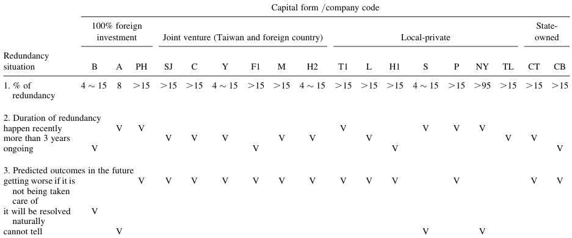

NOTE: complex table shown as an image of the PDF; the text below is a rough machine extraction and may be mis-aligned.

**extracted text (unreliable layout)**

100% foreign investment Joint venture (Taiwan and foreign country) Local-private State-

owned

Redundancy

situation B A PH SJ C Y F1 M H2 T1 L H1 S P NY TL CT CB

2. Duration of redundancy happen recently V V V V V V

more than 3 years V V V V V V V V

ongoing V V V V

3. Predicted outcomes in the future getting worse if it is

not being taken

care of

V V V V V V V V V V V V V

it will be resolved

naturally V

cannot tell V V V

Empirical Research on the Institutional Theory of Downsizing 641

Page 11

The analysis and discussion of the survey results are made in the light of the three main categories of downsizing motivation according to the Institutional Theory of Downsizing proposed by McKinley et al. (2000).

Institutional factors. From the viewpoint of institutional theory, downsizing is adopted because the enterprises follow the social convention: isomorphic actions have their legitimacy. McKinley et al. (1995) proposed that there are three institutional factors affecting the execution of downsizing. They are constraining, imitation and learning. Many companies indicated that the factors of institutional theory are the main motivation behind downsizing actions. According to the respondents, the factors of institutional theory are: the command from higher hierarchy, downsizing as a publicly accepted paradigm, learning from the bench-marked companies. See the downsizing motivation – the consideration of institutional factors in Table 4. Among them, the command from higher hierarchy is the major influencing factor. The decisions of downsizing are possibly influenced by the factors of institutional theory, but are not necessarily carefully evaluated. The findings also reveal that many enterprises downsize to cope with the whole organizational change and to implement business process re-engineering. Currently, business process reengineering (BPR)<sup>5</sup> is recognized as a fad and many managers recognized the concepts of BPR as downsizing.

Social cognition. The consideration of social cognition means that managers recognize downsizing via mutual interactive mental modes and institutional process. On the other hand, after job re-design, the percentage of redundancy is figured out and the downsizing decision is made by top management. Downsizing motivation is the obvious evidence of the social cognition processes of mangers. Collectively, these top managers instil the concepts of employee self-reliance and de-bureaucratization and, furthermore, put the concepts into action. Simultaneously, people generally accept that organizations must re-organize in the dynamic environment, and therefore that downsizing is inevitable. Apart from that, downsizing also relates to external social interaction. From the interviews, we find out that the managers in Taiwan usually have many opportunities to get access to up-to-date management knowledge, such as managerial journals, further education, practical and academic seminars or similar social functions. And these social learning processes include regional, national and international meetings. Part of the downsizing

642 C.-F. Tsai et al.

Page 12

Table 3. The downsizing motivation the -consideration of economic factors

[output not shown]

NOTE: table converted from PDF layout to HTML text; cell boundaries are reconstructed. See PDF if exact alignment matters.

Downsizing motivation

100% foreign investment Joint venture (Taiwan & foreign

country) Local-private State-

owned

B A PH SJ C Y F1 M H2 T1 L H1 S P NY TL CT CB

Stagnant profitability or

decline V V V V V V V V V V V V

New business model V V V V V V V V

Unclear core competency V

employees without

competitive advantages V V V V V V V V V V

Depression without recovery V

Empirical Research on the Institutional Theory of Downsizing 643

Page 13

Table 4. The downsizing motivation -the consideration of institutional factors

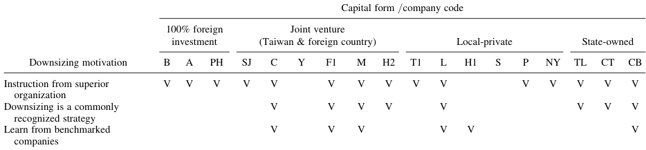

NOTE: complex table shown as an image of the PDF; the text below is a rough machine extraction and may be mis-aligned.

**extracted text (unreliable layout)**

Downsizing motivation

100% foreign investment Joint venture

(Taiwan & foreign country) Local-private State-owned

B A PH SJ C Y F1 M H2 T1 L H1 S P NY TL CT CB

Instruction from superior

organization V V V V V V V V V V V V V V V

Downsizing is a commonly

recognized strategy V V V V V V V V

Learn from benchmarked

companies V V V V V V

644 C.-F. Tsai et al.

Page 14

motivation is from the interaction with managers from different fields, academic scholars and business consultants. After the social interaction, managers learn that downsizing is an effective strategy to reorganize the companies. In addition, Table 5 shows that many companies downsize because other bench-marked companies also do the same. The management patterns of the benchmarked companies have leading effects.

Ethical acceptability. Lastly, the ethical acceptability is discussed. From Table 6, we find that all the companies that downsize comply with the requirements of local laws and regulations, but are inconsistent in respecting employees’ basic human rights. In fact, companies downsize mainly for profitability. But considering the corporate images and the downsizing effectiveness, they also have to obey the rules. Respect of employees’ human rights and the principles of justices are different in different cultural contexts and the level of social institutionalization. For example, foreign direct invested (FDI) companies are consistent in ethical principles because they are strongly influenced by home countries.

Summary

Compound motivation

The Comparisons of Downsizing Motivation between the Subsidiaries of MNCs and the Local Private Enterprises

Except for Company Y, the downsizing motivation of all the subsidiaries of MNC is influenced by the wishes of parent companies or the regional HQ. Compared with the purely foreign-invested companies, joint-ventured and local privately-owned companies tend to be influenced by economic factors. More subsidiaries of MNCs execute business process re-engineering than the local privately-owned companies. Therefore, the downsizing motivation is formed through the process of social cognition. During the process of social cognition, the ethical principles from purely foreign-invested enterprises are more definite and consistent.

The following three interviews (local private, joint ventured and purely foreign-invested companies) illustrate the compound reasons and differences in downsizing motivations.

Empirical Research on the Institutional Theory of Downsizing 645

Page 15

Table 5. The downsizing motivation -the consideration of social recognition

|  |  |  | Capitalform/companycode |  |  |  |  |  |  |  |  |
| --- | --- | --- | --- | --- | --- | --- | --- | --- | --- | --- | --- |
|  | 100%foreign | Jointventure(Taiwan&foreign |  |  |  |  |  |  |  | State- |  |
|  | investment |  | country) |  | Local -private |  |  |  |  | owned |  |
| Downsizingmotivation | B A PH | SJ C | Y F1 M H2 | T1 L | H1 | S | P | NY | TL | CT | CB |
| Overallsystemchanges | V V V | V | V V V V |  | V | V |  |  |  | V | V |
| Businessprocessreengineering Actualizationofmanagement | V V | V | V V V V V | V | V |  |  |  |  | V |  |
| knowledge Comparisonwiththebenchmarked enterprise | V | V | V | V | V | V |  |  | V | V | V |

NOTE: table converted from PDF layout to HTML text; cell boundaries are reconstructed. See PDF if exact alignment matters.

Downsizing motivation

100% foreign investment Joint venture (Taiwan & foreign

country) Local-private State-

owned

B A PH SJ C Y F1 M H2 T1 L H1 S P NY TL CT CB

Overall system changes V V V V V V V V V V V V

Business process reengineering V V V V V V V V V

Actualization of management

knowledge V V

Comparison with the benchmarked

enterprise V V V V V V V V V

646 C.-F. Tsai et al.

Page 16

Table 6. Enterprise’s ethic principles and the social responsibility perception

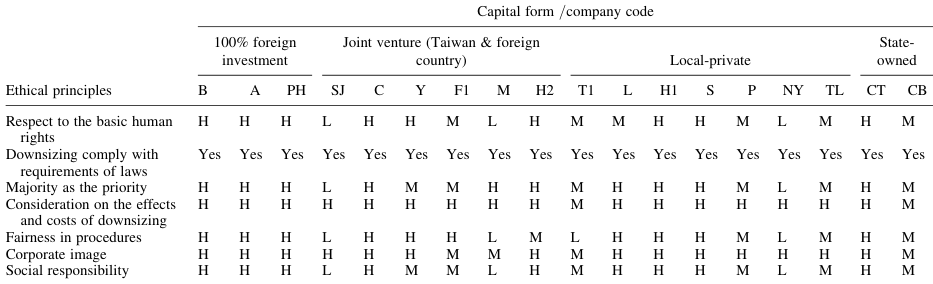

NOTE: complex table shown as an image of the PDF; the text below is a rough machine extraction and may be mis-aligned.

**extracted text (unreliable layout)**

Ethical principles

100% foreign investment Joint venture (Taiwan & foreign

country) Local-private State-

owned

B A PH SJ C Y F1 M H2 T1 L H1 S P NY TL CT CB

Respect to the basic human

rights H H H L H H M L H M M H H M L M H M

Downsizing comply with

requirements of laws Yes Yes Yes Yes Yes Yes Yes Yes Yes Yes Yes Yes Yes Yes Yes Yes Yes Yes

Majority as the priority H H H L H M M H H M H H H M L M H M

Consideration on the effects

and costs of downsizing H H H H H H H H H M H H H H H H H M

Fairness in procedures H H H L H H H L M L H H H M L M H M

Corporate image H H H H H H M M H M H H H H H H H M

Social responsibility H H H L H M M L H M H H H M L M H M

Note: H: high; M: moderate; L: low

Empirical Research on the Institutional Theory of Downsizing 647

Page 17

The downsizing decision is reached by the President, VP, General Manager, VP of Business Unit, and HR Heads. The downsizing decision is made according to profits and costs. Inefficiency of the organization and too many redundant employees are also the reasons. Even though employees are capable, if the firm’s overall performance is not good, companies still have to take downsizing actions in order to survive [economic factors] . . . Since downsizing is considered as the last resort in most of the countries . . . When downsizing, companies still have to take the way of competitors’ doing and the opinions of, customers and the society into account (institutional consideration). Otherwise, employees will regard the company as a cruel organization. Firms also have to consider interpersonal relationships, too. For example, they do not lay off married couples who work at the same firm, but offer preferential compensation package. Downsizing targets are selected according to their performance. Even top managers and union leaders may become targets. At the first stage of downsizing, employees will be notified in advance. The laid-off compensation will be paid instead in order to avoid unfairness. In the subsequent stage, employees will be informed about the problems and difficulties faced by the firms and are convinced that firms are compelled to take the action [the consideration of business ethics and morality] . . . During recession, downsizing is inevitable. In order to survive, firms will downsize and the downsizing action will comply with the social compliance [institutional consideration]. (VP of Business Unit at a local high technology firm)

After the expiration of patents, competitors appear rapidly. The market competition is tense and the competitors produce better products with the latest and better technology. Comparatively, our production costs are higher than theirs [economic motivation] . . . Our firm has executed BPR for two years which makes the problem of redundancy more serious and obvious. Therefore, it is obvious that some business units have to be merged or downsized. Downsizing has been regarded as a necessary action for firms in order to be more competitive. It is widely accepted and discussed in business conferences or in academic field. If the firms do not downsize when the overall performance is still good, they will be perceived as incapable organizations [institutional consideration]. We have discussed many times at the executive meetings and reached a conclusion: downsizing is the necessary strategy [the process of social cognition] . . . In order to maintain the corporate image and the relationship with the employees, we have to take economic benefits and business ethics into account . . . and at the same time, preferential separation package will be provided to persuade the employees who can’t meet the standard performance to leave. Although it is hard for both our firm and employees, it is vital to stay competitive. (Senior VP of a joint ventured firm)

Originally we did not see the problem of redundancy at our firm, but the parent company in the US based on the high efficiency [economic factors] has asked us to reorganize the subsidiaries in Taiwan [institutional factors] . . . Since downsizing is inevitable, the CEO gathers all department heads to re-design the organization with the guidelines provided by the parent company [social cognition]. After interviews and selections, new working teams are formed. The ones who are not selected will be arranged for other jobs at other subsidiaries. Both firm and the employees benefit from the arrangements. Some employees receive the laid-off compensation and later find a better job. Even for those who cannot be allocated anywhere are still offered a preferential laid-off package . . . We downsize the employees in batches to decrease the impact on employees [the consideration of business ethics]. Totally we have downsized 8% of the workforce, but it is still

648 C.-F. Tsai et al.

Page 18

too early to assess the impact on the overall business performance [economic factors]. (HR director of 100% FDI)

We proposed the following propositions according to the above discussions.

| Proposition1 . | The downsizing motivation is mixed with economic factors insti , - |
| --- | --- |
|  | tutional factors and social cognition . |
| Propositions 2 . | Managers who have gone through the process of BPR or the whole |
|  | system change have stronger social cognition . |
| Propositions 3 . | Compared with the 100% FDI the downsizing motivation of joint ven- , |
|  | tures tends to be more influenced by the institutional factors The . |
|  | motivation is similar tothe local firms . |

NOTE: table converted from PDF layout to HTML text; cell boundaries are reconstructed. See PDF if exact alignment matters.

Institutionalization, Downsizing Strategies and Practice

Summarizing the above analyses, we propose a proposition about downsizing strategies and relevant practices.

Proposition 4. Institutional factor and social cognition both influence downsizing

strategies and related practices.

Conclusions and Suggestions

Our empirical research supported the Institutional Theory of Downsizing proposed by McKinley et al. That is, the motivation of downsizing is mixed with economic factors, institutional factors and social cognition. Moreover, this mixed motivation has also occurred in Taiwan, which is a newly developed country but not a post-industrial country; which contrasts the proposition of McKinley et al. We have explained the Institutional Theory of Downsizing and the relevant practices in downsizing strategies and execution. It is obvious that the Institutional Theory of Downsizing not only affects the motivation but also affects the relevant downsizing practices. Most of the enterprises downsize for a profitable purpose, but to maintain a fair corporate image, the practices should comply with the social norms. The respect of employees’ human rights and principles of justice could be different due to various cultural backgrounds and social systems. For example, the ethical principles in foreign-owned enterprises are clear and consistent; however, joint venture subsidiaries or local enterprises tend to be influenced by local culture and social systems. Oliver (1990) has proposed similarly that foreign-sponsored

Empirical Research on the Institutional Theory of Downsizing 649

Page 19

Table 7. Downsizing strategies

[output not shown]

NOTE: table converted from PDF layout to HTML text; cell boundaries are reconstructed. See PDF if exact alignment matters.

Downsizing

strategy

1. Intensity Moderate V V V V V V V V V V V V V V

Acute V V V V V V V V V V

2. Downsizing process Directly V V V V

Downsize after

BPR V V V V V V

Downsize after

re-organization V V V V V V V V

3. Criteria for downsizing Performance V V V V V V V V V V V V V

Value to the

company V V V V V V V V V

Volunteer V V VV

Job statue V

Age (seniority) V V V V V V

Others V V V V V V

4. Alternatives Transfer to other

subsidiaries V V V V V V V

Job enlargement/

Curtailed

working hours

650 C.-F. Tsai et al.

Page 20

Table 8. The severance terms

[output not shown]

NOTE: table converted from PDF layout to HTML text; cell boundaries are reconstructed. See PDF if exact alignment matters.

Severance terms

100% foreign investment Joint venture (Taiwan & foreign country) Local-private State-owned

B A PH SJ C Y F1 M H2 T1 L H1 S P NY TL CT CB

Be notified in

advance V V V V V V V V V V V V V V

Superior package

to legal

requirement

V V V V V V V V V V V V V V V

Outplacement services:

Consultation

service V V V V V V V V V V V V V V

Transfer/job-

seeking/

establish their

own business

V V V V V V V V V V

Empirical Research on the Institutional Theory of Downsizing 651

Page 21

subsidiaries tended to value the local social systems. We also realize that institutionalization and social cognition processes will produce a balancing power in the downsizing practices. It allows enterprises access to the legitimacy in the system and to perform downsizing smoothly. Employees have better opportunity to negotiate and get favourable compensation when leaving. The balancing power is especially important for the management of MNCs in foreign countries.

Research Implications

The evidence for this research comes from Taiwan, but it is worthwhile choosing more sample cases from other cultural backgrounds in order to discuss further the influences of institutional theory of downsizing in cross-cultural contingency. For example, choosing other developing countries, such as China, Malaysia, Thailand as research targets, the generalization of the institutional theory of downsizing will be more concrete. At the same time, it is also interesting to find out if the strategies and actions taken by the downsized employees and the other stakeholders will be also influenced by institutional factors. It is also worthwhile investigating the influences of the institutional motivation and the related strategies on the performance after downsizing (such as the firm performance and the acceptability of the employees). In addition to downsizing, will other prevailing management practices such as BPR, 6s, knowledge management be influenced by institutional factors or the process of social cognition? It will be worthwhile researching this.

Managerial implications. The research has proved that MNCs emphasize global integration. They also focus on local responsiveness when formulating HR managerial practices. For example, the interviewed firms in this research revealed that they downsized because the parent companies asked them to do so. Meanwhile, they still obeyed the local norms and legal requirements. Through the socialization process of the managerial teams, firms can understand the motivation for downsizing and take advantageous strategies and actions. Then, the downsizing action will be effective and comply with the business ethics and further meet the expected goals. Institutionalization can reduce the uncertainty and ensure downsizing can proceed smoothly. Sometimes, firms overemphasize the importance of institutionalization and neglect individual conditions. Therefore, when downsizing, firms have to evaluate carefully both external and internal conditions.

Notes

1. They are the principle of utility, principle of rights and principle of justice. It means that fairness and equality are used to explore ethic behaviours and performance. The three principles are from the normative model of ethical analysis developed by Cavanagh et al. (1981). 2. Yeh (2000) cited from Meyer & Rowan (1997): enterprises have more legitimacy if their behaviours comply with the environmental institution. 3. According to the definition by Bartlett et al. (2003): MNCs are the companies which directly invest in foreign countries and manage the subsidiaries aggressively. 4. According to the definition by Tomasko (1990), mass-scaled downsizing means to downsize 5% to 15%. 5. Champy (1995): he and Hammer published Reengineering the Corporation in 1993. The book intrigued the popularity of business process re-engineering (BPR) and also the trend of downsizing.

652 C.-F. Tsai et al.

Page 22

References

Baron, J. N. & Kreps D. M. (1999) Strategic Human Resources: Frameworks for General Management

(New York: Wiley). Bartlett C. A. et al. (2003) Transnational Management – Text, Cases, and Readings in Cross-Border Manage-

ment (Boston, MA: McGraw-Hill Higher Education). Baum, J. A. C. & Oliver, C. (1991) Institutional linkages and organizational mortality, Administrative Science

Quarterly, 36, pp. 187–218 Budros, A. (1999) A conceptual framework for analyzing why organizations downsizing, Organization Sciences,

10(1), pp. 69–82. Cameron, K. S. (1994) Strategies for successful organizational downsizing, Human Resource Management,

33(2), pp. 189–211. Cascio, W. F. (1993) Downsizing: what do we know? What have we learn?, Academy of Management

Executive, 7(1), pp. 95–106 Cascio, W. F. (2002) Strategies for responsible restructuring, Academy of Management Executive, 16(3), pp. 80–91. Cascio, W. F. et al. (1997) Financial consequences of employment change decisions in major U.S. corporations,

Academy of Management Journal, 40(5), pp. 1175–1189. Carroll, G. R. & Hannan, M. T. (1989) Density dependence in the evolution of population of newspaper organi-

zation, American Sociological Review, 54, pp. 524–541. Cavanagh, G. F. et al. (1981) The ethics of organizational Politics, Academy of Management Review, 6(3), pp.

363–374. Champy, J. (1995) Reengineering Management – The Mandate for New Leadership (New York: Harper

Business). Delery, J. E. & Shaw, J. D. (2001) The strategic management of people in work: review, synthesis and extension,

Research in Personnel and Human Resources Management, 20, pp. 165–197. DiMaggio, P. J. & Powell, W. W. (1983) The iron cage revisited: institutional isomorphism and collective ration-

ality in organizational fields, American Sociological Review, 48, pp. 147–160. DeWitt, R. -L. (1993) The structural consequences of downsizing, Organization Science, 4(1), pp. 30–40. Drew, S. A. W. (1994) Downsizing to improve strategic position, Management Decision, 32(1), pp. 4–11. Ellis, J. (1998) The downside of downsizing, Boston Globe, November 11:A15. Fisher, S. R. & White, M. A. (2000) Downsizing in a learning organization. Are there hidden costs? Academy of

Management Review, 25(1), pp. 224–251. Freeman, S. J. (1999) The gestalt of organizational downsizing: downsizing strategies as package of change,

Human Relations, 52(12), 1505–1541. Freeman, S. J. & Cameron, K. S. (1993) Organizational downsizing- a convergence and reorientation framework,

Organization Science, 4(11), pp. 10–29. Graham, J. & Lam. N. M. (2003) The Chinese negotiation, Harvard Business Review, 81(10), pp. 82–91 Greenhalgh, L. et al. (1988) Determinants of workforce reduction strategies in declining organization, Academy

of Management Review, 13(2), pp. 145–161. Gupta, N. et al. (2000) Correlates of response outcomes among organization key information, Organizational

Research Method, 3, pp. 323–347. Hirschman, C. (2001) The kindest cut, HR Magazine, 46(4), pp. 48–53. Lamertz, K. & Baum, J. A. C. (1998) The legitimacy of organizational downsizing in Canada: an analysis of

explanatory media accounts, Canada Journal of Administration Sciences, 15, pp. 93–107. Landry, J. T. (2004) Downsizing in America: reality, causes, and consequences, Harvard Business Review, 82(2),

pp. 39. McCune, J. T. et al. (1988) Downsizing: practices in manufacturing firms, Human Resource Management, 27(2),

pp. 145–161. McKee-Ryan, F. M. & Kinicki, A. J. (2002) Coping job loss: a life-facet perspective, International Review of

Industrial and Organizational Psychology, 17, pp. 1–29. McKinley, W. et al. (1995) Organizational downsizing: constraining, cloning, learning, The Academy of

Management Executive, 9(3), pp. 32–44. McKinley, W. et al. (2000) A socio-cognitive interpretation of organizational Downsizing, Academy of

Management Review, 25(1), pp. 227–243. Mentzer, M. S. (1996) Corporate downsizing and profitability in Canada, Canada Journal of Administration

Sciences, 13, pp. 237–250.

Empirical Research on the Institutional Theory of Downsizing 653

Page 23

Meyer, J. & Rowan, E. (1997) Institutionalized organizations: formal structure as myth and ceremony. American

Journal of Sociology, 83, pp. 340–363. Millward, L. J. & Brewerton, P. M. (2002) Psychological contracts: employee relations for the twenty-first

century?, International Review of Industrial and Organizational Psychology, 15, pp. 1–61. Mone, M. A. (1997) How we got along after the downsizing: post-downsizing trust as a double-edged sword,

Public Administration Quarterly, 21(3), pp. 309–336. Naumann, E. S. et al. (1995) The roles of organizational support and justice during a layoff, Academy of Manage-

ment Journal, Special issue, pp. 89–95. Norman, P. M. (1995) An institutional interpretation of organizational downsizing. Paper presented at the annual

meeting of Southern Management Association, Orlando, Florida. Oliver, C. (1990) Determinants of inter-organizational relationships: integration and future direction, Academy of

Management Review, 15(2), pp. 241–265. Oliver, C. (1991) Strategic response to institutional processes, Academy of Management Review, 16, pp. 145–179. Oliver, C. (1997a) Sustainable competitive advantage: combining institutional and resource-based views,

Strategic Management Journal, 18(9), pp. 697–713. Oliver, C. (1997b) The influence of institutional and task environment relationships on organizational perform-

ance: the Canadian construction industry, The Journal of Management Studies, 34(1), pp. 99–124. Prusak, L. & Cohen, D. (2001) How to invest social capital, Harvard Business Review, 79(6), pp. 86–93. Rigby, D. (2002) Look before you lay off, Harvard Business Review, 80(4), pp. 20–21. Scott, W. R. (1987) The adolescence of institutional theory, Administrative Science Quarterly, 32, pp. 493–511. Shah, P. P. (2000) Network destruction: the structural implications of downsizing, Academy of Management

Journal, 43(1), pp. 101–112. Sherer, P. D. & Leblebici, H. (2001) Bring variety and change into strategic human resource management

research, Research in Personnel and Human Resources Management, 20, pp. 199–230. Sun, B. -C. & Yeh, Y. -C. (1996) The study of downsizing on remaining employees’ organizational behaviors,

Personnel Monthly, 23(2), pp. 26–28. Sun, B. -C. (1997a) The strategies in organizational employees downsizing (I), Personnel Monthly, 23(5), pp. 12–19. Sun, B. -C. (1997b) The strategies in organizational employees downsizing (II), Personnel Monthly, 23(6), pp.

16–31. Tomasko, R. M. (1990) Downsizing – Reshaping the Corporation for the Future (New York: American Manage-

ment Association). Tomaskovic-Devey, D. et al. (1994) Organizational survey nonresponse, Science Quarterly, 39(3), pp. 439–457. Tsai, P. C. F. (2001) The influential factors on downsizing in a joint-venture company – the case of Capco Pet-

rochemical Co., National Sun-Yat Sun University. Wang, F. S. & Tsai, F. L. (2003) Enterprise ethics climate, ethical behaviors and business social performance,

Asia-Pacific Economic and MGT Review, 6(2), pp. 103–119. Yeh, K. -S. (2000) Analytic model of business ethic and institutional change, Asia-Pacific Economic and MGT

Review, 3(2), pp. 1–13.

654 C.-F. Tsai et al.